# 20181_M2.955_PAC2-Solucio

[figure not shown]

M2.955 · Models avançats de mineria de dades · PAC2

2018-1 · Màster universitari en Ciència de dades (Data science)

Estudis de Informàtica, Multimèdia i Telecomunicació

# PAC 2: Mètodes no supervisats

Al llarg d'aquesta pràctica veurem com aplicar diferents tècniques no supervisades així com algunes de les seves aplicacions reals:

1. **Clustering clàssic**: k-means i la regla del colze.
2. **Clustering amb formes i feature engineering**
3. **Reducció de dimensionalitat**: PCA i t-SNE.
4. **Aplicació**: Agrupació de documents

Per a això necessitarem les següents llibreries:

```python
import random

import numpy as np
import pandas as pd
from sklearn import cluster      # Algorismes de clustering
from sklearn import datasets     # Crear datasets

# Visualitzacio
import matplotlib.pyplot as plt
import seaborn as sns

%matplotlib inline
```

## 1. Clustering clàssic: k-means i la regla del colze (2 punts)

Anem a generar un dataset compost per $n$ núvols de punts, on $n$ serà un nombre aleatori entre 2 i 4, usant el mòdul `datasets` de scikit-learn.

```
Hi ha 1500 punts en 2 dimensions (repartits en 3 clusters)
```

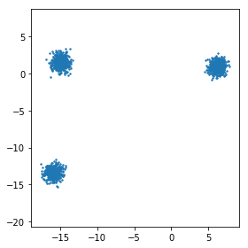

```python
N_SAMPLES = 1500
MIN_CLUSTERS = 2
MAX_CLUSTERS = 4
X, y = datasets.make_blobs(n_samples=N_SAMPLES, # Nombre de punts
                           n_features=2,        # Nombre de dimensions
                           centers=random.randint(MIN_CLUSTERS, MAX_CLUSTERS),
                           center_box=(-20, 20),
                           cluster_std=.6)
print('Hi ha {} punts en {} dimensions (repartits en {} clusters)'.format(X.shape[0], X.shape[1], y.max() + 1))
fig, ax = plt.subplots(1, 1, figsize=(4, 4))
ax.scatter(X[:,0], X[:,1], s=2)
ax.axis('equal')
plt.tight_layout()
```

Una tècnica per estimar $k$ és, com s'explica a la teoria:

> Els criteris anteriors (minimització de distàncies intra grup o maximització de distàncies inter grup) poden usar-se per establir un valor adequat per al paràmetre k. Valors k per als quals ja no s'aconsegueixen millores significatives en l'homogeneïtat interna dels segments o l'heterogeneïtat entre segments diferents, haurien de descartar-se.

El que popularment es coneix com *regla del colze*.

Primer cal calcular la suma dels errors quadràtics ([*SSE*](https://bl.ocks.org/rpgove/0060ff3b656618e9136b)) que consisteix en la suma de tots els errors (distància de cada punt al seu centroide assignat) al quadrat.

$$SSE = \sum_{i=1}^{K} \sum_{x \in C_i} euclidean(x, c_i)^2$$

On $K$ és el nombre de clusters a buscar per *k-means*, $x \in C_i$ són els punts que pertanyen al i-èsim cluster, $c_i$ és el centroide del cluster $C_i$ (al qual pertanty el punt $x$), i $euclidean$ és la [distància euclídea](https://en.wikipedia.org/wiki/Euclidean_distance).

Aquest procediment realitzat per a cada possible valor $k$, resulta en una funció monòtona decreixent, on l'eix $x$ representa els diferents valors de $k$, i l'eix $y$ el $SSE$. Intuïtivament es podrà observar un significatiu descens de l'error, que indicarà el valor idoni de $k$.

**Es demana realitzar la representació gràfica de la regla del colze al costat de la seva interpretació, utilitzant la llibreria `matplotlib` i la implementació en scikit-learn de [*k-means*](http://scikit-learn.org/stable/modules/generated/sklearn.cluster.KMeans.html).**

**Implementació:** càlcul i visualització de la regla del colze.

**Solució:**

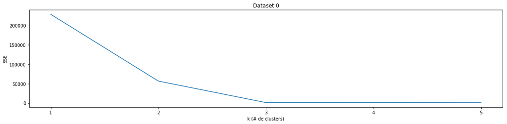

```python
#############################################
# SOLUCIÓ                                   #
#############################################

from typing import List
from mypy_extensions import NoReturn

def plot_elbow_rule(datasets: List[np.array],
                    min_k: int = 1,
                    max_k: int = MAX_CLUSTERS+1) -> NoReturn:
    """Computes and shows SSE for each value of k in k-means.

    This is a generic solution that receives a list containing datasets,
    and shows a plot for each datset.

    Args:
        datasets: list
            A list of np.array with shape (points, dimensions).
        min_k: int
            The lowest value of k to try.
        max_k: int
            The highest value of k to try.
    """
    fig, ax = plt.subplots(1, len(datasets), figsize=(16, 4))
    for i, a in zip(range(len(datasets)), ax if type(ax) == np.ndarray else (ax,)):
        x = range(min_k, max_k + 1)
        y = []
        X = datasets[i]
        for nc in x:
            kmeans = cluster.KMeans(n_clusters=nc)
            dists = kmeans.fit_transform(X)
            y.append(np.sum(np.min(dists, axis=1) ** 2))
        a.plot(x, y)
        a.set_xlabel('k (# de clusters)')
        a.set_ylabel('SSE')
        a.set_title('Dataset {}'.format(i))
        a.set_xticks(range(min_k, max_k + 1))
    plt.tight_layout()

dists = plot_elbow_rule([X])
```

**Anàlisi:** Què s'interpreta en la gràfica? Com podria millorar-se l'elecció de $k$?

**Solució:**  
**Compte, el número de clusters del dataset canvia en cada execució, per tant, la gràfica i l'anàlisi poden ser diferents per a cada estudiant.**  
Tal com s'esperava, en la gràfica anterior es pot observar com a mesura que augmenta el nombre de clústers es va reduint l'error. A partir de $k = 3$, l'error es redueix significativament i no s'aprecia una notable reducció de l'error en augmentar el valor de $k$. Pel que una decisió raonable és pensar que el nombre de clústers originals és de 3.  
Es pot afinar més amb una mètrica que no només utilitzi la distància *intragrup* sinó també la *inter-grup*, tal com apareix en la teoria.

**[OPCIONAL] Implementació:** algorisme *k-means* des de zero.

En aquest cas, amb 2 dimensions, és molt senzill inferir el nombre de clústers visualitzant les dades. Però aquest mètode és de gran utilitat quan es compta amb dades d'alta dimensionalitat.

## 2. Clustering amb formes i feature engineering (4 punts)

Però no tots els datasets són com els de l'exercici anterior. Per a aquesta segona part anem a emprar el conjunt de dades següent:

```python
data_circles = ('circles', *datasets.make_circles(n_samples=N_SAMPLES, factor=.5, noise=.05))
```

On *data_circles* és una tupla amb tres posicions: el nom del dataset i els dos valors retornats per la funció que genera el dataset:

```python
datasets.make_circles?
```

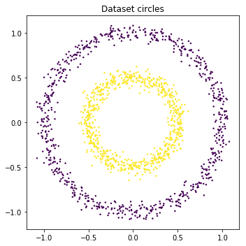

```python
fig, ax = plt.subplots(1, 1, figsize=(5, 5))
ax.scatter(data_circles[1][:,0], data_circles[1][:,1], c=data_circles[2], s=2)
ax.set_title('Dataset {}'.format(data_circles[0]))
plt.tight_layout()
```

### 2 a. Trobant els clusters amb *k-means*

**Implementació:** aplica la regla del colze per decidir el valor de $k$ en aquest dataset.

**Solució:**

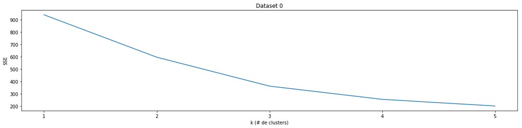

```python
#############################################
# SOLUCIÓ                                   #
#############################################

plot_elbow_rule([data_circles[1]])
```

**Implementació:** aplica *k-means* amb el valor de $k$ escollit per aquest dataset.  
Visualitza el resultat en un *scatter plot* representant cada clúster amb un color diferent.

**Solució:**

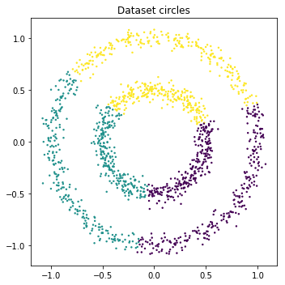

```python
#############################################
# SOLUCIÓ                                   #
#############################################

fig, ax = plt.subplots(1, 1, figsize=(5, 5))
kmeans = cluster.KMeans(n_clusters=3)
dists = kmeans.fit_transform(data_circles[1])
ax.scatter(data_circles[1][:,0], data_circles[1][:,1], c=np.argmax(dists, axis=1), s=2)
ax.set_title('Dataset {}'.format(data_circles[0]))
plt.tight_layout()
```

**Anàlisi:** Què ha passat? Explica els motius pels quals creus que s'ha produït aquest resultat.

**Solució:**  
Usant *k-means* amb distància euclidiana assumim que els clústers són n-esferes. A la pràctica podem veure-ho com una tessel·lació de Voronoi, que és el que s'observa en els resultats anteriors.  
És normal que no es produeixin els resultats esperats perquè els clústers tenen diferents formes i no se cenyeixen a cel·les de Voronoi.

### 2 b. Més enllà de *k-means*: algorismes basats en la densitat

En aquest apartat es demana aplicar clustering per densitat com DBSCAN al dataset anterior per trobar els dos clusters inicials.

**Implementació:** Prova la implementació de [DBSCAN en scikit-learn](http://scikit-learn.org/stable/modules/generated/sklearn.cluster.DBSCAN.html) jugant amb els paràmetres *eps* i *min_samples* per trobar les 2 estructures subjacents (i *outliers*).

**Solució:**

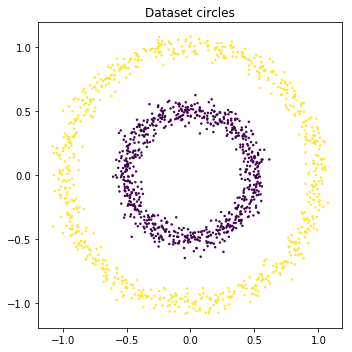

```python
#############################################
# SOLUCIÓ                                   #
#############################################

model = cluster.DBSCAN(eps=.1, n_jobs=-1)
clusters = model.fit(data_circles[1])

fig, ax = plt.subplots(1, 1, figsize=(5, 5))
ax.scatter(data_circles[1][:,0], data_circles[1][:,1], c=clusters.labels_, s=2)
ax.set_title('Dataset {}'.format(data_circles[0]))
plt.tight_layout()
```

**Anàlisi:** Què ha passat? Explica els motius pels quals creus que s'ha produït aquest resultat.

**Solució:**  
Fent servir *DBSCAN* amb un eps de 0.1 s'aconsegueix trobar els dos clusters perquè els dos anells tenen una densitat constant al llarg d'ells mateixos i estan suficientment separats. Això fa que l'algorisme, al guiar-se per la densitat de punts, pugui distingir les dues estructures.

### 2 c. Més enllà de *k-means*: algorismes jeràrquics

En aquest apartat es demana visualitzar mitjançant un [dendrograma](https://en.wikipedia.org/wiki/Dendrogram) la construcció progressiva dels grups mitjançant un algoritme jeràrquic aglomeratiu (estratègia *bottom-up*). Amb això es pretén trobar un mètode gràfic per determinar el nombre de clústers en cada escenari.

**Implementació:** Prova la implementació de [clustering jeràrquic de scipy](https://docs.scipy.org/doc/scipy/reference/cluster.hierarchy.html) amb diferents [criteris d'enllaç o *linkage*](https://en.wikipedia.org/wiki/Hierarchical_clustering#Linkage_criteria) permetent identificar els clusters subjacents (mostrant el seu resultat) i el seu dendrograma

**Solució:**

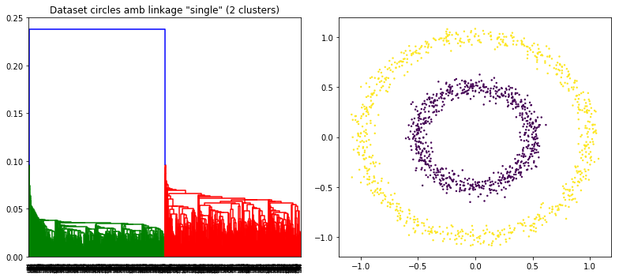

```python
#############################################
# SOLUCIÓ                                   #
#############################################

from scipy.spatial.distance import pdist
from scipy.cluster.hierarchy import dendrogram, linkage, fcluster


fig, ax = plt.subplots(1, 2, figsize=(11, 5))
dendrogram(linkage(pdist(data_circles[1]), 'single'), ax=ax[0])
ax[0].set_title('Dataset {} amb linkage "{}" ({} clusters)'.format(data_circles[0], 'single',
                                                                   np.max(data_circles[2]) + 1))
cluster_idx = fcluster(linkage(pdist(data_circles[1]), 'single'), t=.2, criterion='distance')
ax[1].scatter(data_circles[1][:, 0], data_circles[1][:, 1], c=cluster_idx, s=2)
plt.tight_layout()
```

**Anàlisi:** Interpreta el dendrograma i comenta quin criteri d'enllaç es comporta millor. Per què?

**Solució:**
L'enllaç simple és el que, per a aquest dataset, permet distingir millor els clústers esperats. L'enllaç simple, definit com la mínima distància entre elements de cada clúster:
$$d(A, B)\min\{\,d(x,y):x\in A,\,y\in B\,\}$$
On $x$ i $i$ són elements de diferents clústers ($A$ i $B$). La intuïció darrere d'aquest criteri d'enllaç és anar ajuntant els clústers a través dels seus punts més pròxims. D'aquesta manera, es van dibuixant les formes dels clústers, permetent trobar formes complexes ben separades entre elles.

**Anàlisi:** Què ha passat? Explica els motius pels quals creus que s'ha produït aquest resultat.

**Solució:**  
Usant *agrupament jeràrquic* i un enllaç simple, s'aconsegueixen trobar els dos clusters perquè els dos anells tenen una densitat constant al llarg d'ells mateixos i estan suficientment separats com per anar agragant punts poc a poc de manera que el salt necessari per unir els dos grups és molt significatiu.

### 2 d. *Feature engineering* i agrupament

Alguns dels algorismes anteriors es basen en unes suposicions que no es complien en aquest dataset. Moltes vegades, enlloc d'optar per algorismes més complexes o que requereixen més poder computacional, es poden transformar les dades per a poder aplicar amb èxit les tècniques més simples. Aquest és un exemple molt clar de *feature engineering*.

**Implementació:** Transforma els punts anteriors del dataset a un nou espai de 2 dimensions:

- Radi, o distància al punt (0,0)
- Angle, respecte al vector (1,0)

Per tal que totes les dimensions tinguin el mateix pes, haurem de [normalitzar-les entre 0 i 1 d'acord amb el seu màxim i mínim](http://scikit-learn.org/stable/modules/generated/sklearn.preprocessing.MinMaxScaler.html).  
Visualitza els punts del "nou" dataset.

**Solució:**

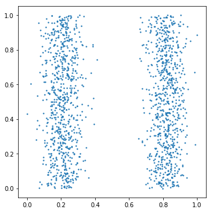

```python
#############################################
# SOLUCIÓ                                   #
#############################################
import math

from sklearn.preprocessing import MinMaxScaler

radius = np.apply_along_axis(lambda x: np.sqrt(x[0] ** 2 + x[1] ** 2), 1, data_circles[1])
angle = np.apply_along_axis(lambda x: math.acos(x[0] / math.sqrt(x[0] ** 2 + x[1] ** 2)), 1, data_circles[1])

radius = MinMaxScaler().fit_transform(radius.reshape(-1, 1))
angle = MinMaxScaler().fit_transform(angle.reshape(-1, 1))

fig, ax = plt.subplots(1, 1, figsize=(5, 5))
ax.scatter(radius, angle, s=2)
plt.tight_layout()
```

**Anàlisi:** Què creus que passarà a l'aplicar els algorismes anteriors a aquest "nou" dataset?

**Solució:**  
Abans l'algorisme *k-means* no funcionava, perà ara sí que es compleixen les suposicions de l'algorisme, així que *k-means* hauria d'indentificar els grups correctament.

**Implementació:** Aplica cadascun dels algorismes d'agrupament anteriors que no han pogut identificar adequadament els dos clusters originals per tractar de trobar-los en aquest "nou" espai. Ajusta els paràmetres necessaris per facilitar la seva detecció.  
Par cada algorisme, visualitza els clusters trobats en 2 imatges:

- En el "nou" espai (radi i angle).
- En l'espai original (posició x i y), però NO amb les etiquetes (pertença a un o altre cluster) obtingudes a l'aplicar els algorismes sobre el dataset original, sinó amb les etiquetes obtingudes al realitzar el clustering en el "nou" espai. A veure si així s'aconsegueixen resoldre els problemes inicials.

**Solució:** Ho fem per *k-means* que era l'únic que no podia trobar els dos clusters.

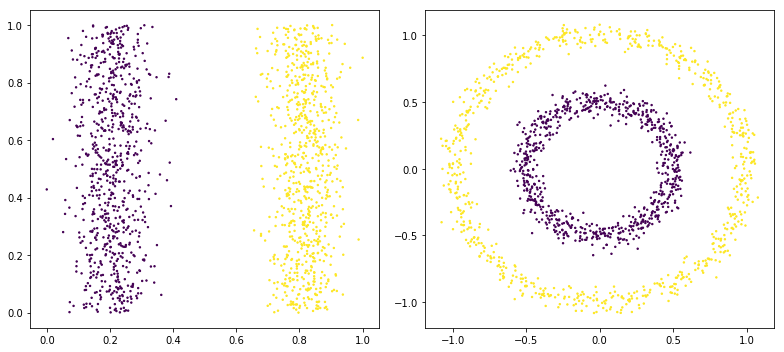

```python
#############################################
# SOLUCIÓ                                   #
#############################################

fig, ax = plt.subplots(1, 2, figsize=(11, 5))
kmeans = cluster.KMeans(n_clusters=2)
dists = kmeans.fit_transform(np.hstack([radius, angle]))
ax[0].scatter(radius, angle, c=np.argmax(dists, axis=1).reshape(-1, 1), s=2)
ax[1].scatter(data_circles[1][:,0], data_circles[1][:,1], c=np.argmax(dists, axis=1), s=2)
plt.tight_layout()
```

## 3. Reducció de dimensionalitat: PCA i t-SNE (1 punt)

### 3 a. PCA

El [dataset Iris](https://es.wikipedia.org/wiki/Iris_flor_conjunto_de_datos) conté 4 atributs sobre tres tipus de flors.

```python
iris = datasets.load_iris()
X = iris.data   # np.array amb shape (150, 4)
y = iris.target # np.array amb shape (150,)
```

En excedir les 3 dimensions necessitarem més d'una visualització per entendre les dades.

Per solucionar-ho, una alternativa és usar els [*pair plots*](http://seaborn.pydata.org/generated/seaborn.pairplot.html) que mostren parells de dimensions per intentar donar una visió global a partir d'un [DataFrame](https://pandas.pydata.org/pandas-docs/stable/dsintro.html):

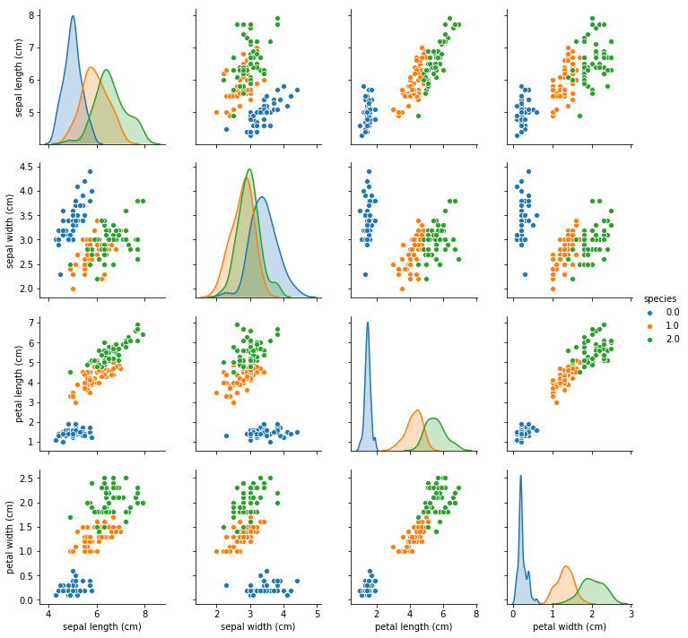

```python
# DataFrame
iris_df = pd.DataFrame(np.hstack([X, y.reshape(-1, 1)]), columns=iris.feature_names + ['species'])
sns.pairplot(iris_df, vars=iris.feature_names, hue="species")
```

Com a alternativa a les múltiples gràfiques que generen els *pair plots*, es planteja utilitzar una tècnica de reducció de dimensionalitat per passar de 4 dimensions a 2. Cal notar que gràfiques com *longitud de pètal* vs *amplada de pètal* mostren certa separabilitat (els 3 tipus de flors estan aparentment separats).

**Implementació:** Realitzar una reducció de dimensionalitat amb PCA per passar de 4 dimensions a 2 i crear una visualització on el color dels punts depengui del tipus de flor a la qual pertany.

**Solució:**

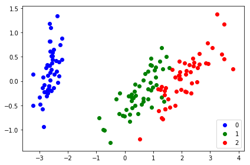

```python
#############################################
# SOLUCIÓ                                   #
#############################################

from sklearn import decomposition

X_prime = decomposition.PCA(n_components=2).fit_transform(X)
for i, color in zip(range(3), ['b', 'g', 'r']):
    indexes = y == i
    plt.scatter(X_prime[indexes,0], X_prime[indexes,1], c=color, label=str(i))
plt.legend(loc='best')
plt.tight_layout()
```

**Anàlisi:** El resultat de la reducció de dimensionalitat manté la separabilitat? Era d'esperar? Per què?

**Solució:**  
- El resultat és separable.  
- No, no és un dels objetius de PCA.  
- Perquè PCA tracta de maximitzar la variància després de la projecció per reduir la dimensionalitat, i en cap moment té informació de les etiquetes (no és supervisat, per això està en aquesta pràctica!).

### 3 b. t-SNE (t-distributed Stochastic Neighbor Embedding)

L'ús de tècniques de reducció de dimensionalitat és de gran utilitat quan aquesta és molt alta. Per exemple, el [dataset Digits](http://scikit-learn.org/stable/auto_examples/classification/plot_digits_classification.html) conté 1797 imatges de nombres del 0 al 9, de 8 per 8 píxels. Si es pren cada píxel com una dimensió, això es tradueix en què cada mostra té 64 dimensions!

```python
digits = datasets.load_digits()
X = digits.data   # np.array amb shape (1797, 64)
y = digits.target # np.array amb shape (1797,)
```

Exemple dels 24 primers números de 8 per 8 píxels al costat de la seva etiqueta presents al dataset:

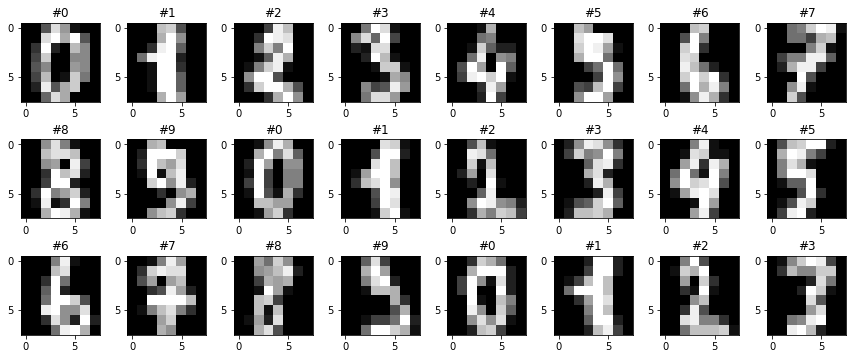

```python
fig, ax = plt.subplots(3, 8, figsize=(12, 5))
for i, axis in zip(range(24), ax.reshape(-1)):
    axis.imshow(X[i,:].reshape(8, 8), cmap='gray')
    axis.set_title('#{}'.format(y[i]))
plt.tight_layout()
```

Amb un nombre tan elevat de dimensions perd sentit visualitzar el dataset amb un *pair plot* i apareixen altres perills com la [maledicció de la dimensionalitat](https://en.wikipedia.org/wiki/Curse_of_dimensionality). Per reduir la seva dimensió i així entendre l'estructura de les dades en alta dimensionalitat hi ha diferents alternatives amb resultats molt diferents.

**Implementació:** Realitzar una reducció de dimensionalitat amb PCA per passar de 64 dimensions a 2 i crear una visualització on el color dels punts depengui del dígit que pertany.

**Solució:**

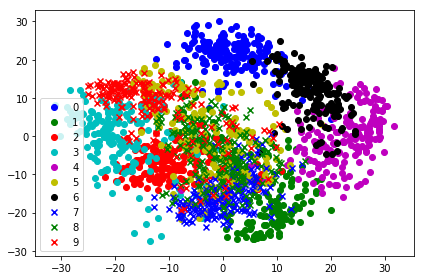

```python
#############################################
# SOLUCIÓ                                   #
#############################################

X_prime = decomposition.PCA(n_components=2).fit_transform(X)
for i, color, marker in zip(range(10), ['b', 'g', 'r', 'c', 'm', 'y', 'k'] * 2, ['o'] * 7 + ['x'] * 7):
    indexes = y == i
    plt.scatter(X_prime[indexes,0], X_prime[indexes,1], c=color, marker=marker, label=str(i))
plt.legend(loc='best')
plt.tight_layout()
```

**Anàlisi:** El resultat de la reducció de dimensionalitat manté la separabilitat? Era d'esperar? Per què?

**Solució:**  
- Aquesta vegada el resultat no és separable.  
- No, no és un dels objetius de PCA.  
- Perquè PCA tracta de maximitzar la variància després de la projecció per reduir la dimensionalitat, no tracta de mantenir la seva estructura.

L'algoritme [t-SNE](https://en.wikipedia.org/wiki/T-distributed_stochastic_neighbor_embedding) desenvolupat per [van der Maaten y Hinton](https://lvdmaaten.github.io/tsne/) difereix de PCA en què no tracta de maximitzar la variància explicada. Intuïtivament, t-SNE tracta que el veïnatge d'un punt en baixa dimensionalitat sigui la mateixa que l'original. Partint d'una localització aleatòria de cada punt, corregeix la seva posició de forma iterativa tractant de minimitzar la distància als seus veïns originals fins a convergir.

Per a això, t-SNE disposa de diversos [paràmetres](https://distill.pub/2016/misread-tsne/) que poden modificar dràsticament el resultat. Pel que recomana conèixer el seu funcionament abans d'aplicar la tècnica.

**Implementació:** Realitza una reducció de dimensionalitat amb t-SNE per passar de 64 dimensions a 2 i crea una visualització on el color dels punts depengui del dígit que pertany.

**Solució:**

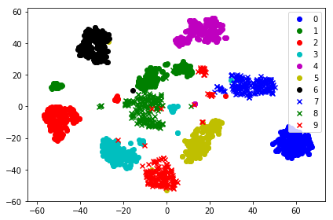

```python
#############################################
# SOLUCIÓ                                   #
#############################################

from sklearn import manifold

X_prime = manifold.TSNE(n_components=2).fit_transform(X)
for i, color, marker in zip(range(10), ['b', 'g', 'r', 'c', 'm', 'y', 'k'] * 2, ['o'] * 7 + ['x'] * 7):
    indexes = y == i
    plt.scatter(X_prime[indexes,0], X_prime[indexes,1], c=color, marker=marker, label=str(i))
plt.legend(loc='best')
plt.tight_layout()
```

**Anàlisi:** El resultat de la reducció de dimensionalitat manté la separabilitat? Era d'esperar? Per què?

**Solució:**  
- Ara sí que el resultat aparenta ser separable.  
- El més probable és que sí, ja que en alta dimensionalitat ho era.  
- Perquè t-SNE tracta de mantenir en baixa dimensionalitat els veïns que un punt té en alta dimensionalitat, intentant mantenir així part de la seva estructura.

## 4. Aplicació: agrupació de documents (3 punts)

### 4 a. Càrrega i preparació de les dades

En aquest problema s'utilizarà el dataset [*20 news group*](https://archive.ics.uci.edu/ml/machine-learning-databases/20newsgroups-mld/20newsgroups.data.html), amb 20 categories de textos, dels quals se'n seleccionaran 3. L'objectiu és trobar grups de textos (preferiblement de la mateixa categoria) a través de les paraules que els formen.

El primer apartat consisteix en carregar el dataset i preparar les dades (tasca que normalment ocupa entre el 70 i 80% del temps d'un projecte de mineria de dades), en aquest cas els textos.

```python
data = datasets.fetch_20newsgroups(categories=['rec.autos', 'rec.sport.baseball', 'soc.religion.christian'])
texts, targets = data['data'], data['target']
```

On `texts` és una llista amb els articles i `targets` és un vector amb l'índex de la categoria a la que pertany cada text.

La neteja del text hauria de convertir el que tenim inicialment:

```python
print(texts[1])
```

```
From: aas7@po.CWRU.Edu (Andrew A. Spencer)
Subject: Re: Too fast
Organization: Case Western Reserve University, Cleveland, OH (USA)
Lines: 25
Reply-To: aas7@po.CWRU.Edu (Andrew A. Spencer)
NNTP-Posting-Host: slc5.ins.cwru.edu


In a previous article, wrat@unisql.UUCP (wharfie) says:

>In article <1qkon8$3re@armory.centerline.com> jimf@centerline.com (Jim Frost) writes:
>>larger engine.  That's what the SHO is -- a slightly modified family
>>sedan with a powerful engine.  They didn't even bother improving the
>>*brakes.*
>
>	That shows how much you know about anything.  The brakes on the
>SHO are very different - 9 inch (or 9.5? I forget) discs all around,
>vented in front.  The normal Taurus setup is (smaller) discs front,
>drums rear.

one i saw had vented rears too...it was on a lot.
of course, the sales man was a fool..."titanium wheels"..yeah, right..
then later told me they were "magnesium"..more believable, but still
crap, since Al is so m uch cheaper, and just as good....


i tend to agree, tho that this still doesn't take the SHO up to "standard"
for running 130 on a regular basis.  The brakes should be bigger, like
11" or so...take a look at the  ones on the Corrados.(where they have
braking regulations).

DREW
```

en quelcom semblant a:

`In previous article UUCP wharfie says In article centerline com com Jim Frost writes larger engine That's what the SHO is slightly modified family sedan with powerful engine They didn't even bother improving the *brakes That shows how much you know about anything The brakes on the SHO are very different inch or forget discs all around vented in front The normal Taurus setup is smaller discs front drums rear one saw had vented rears too it was on lot of course the sales man was fool titanium wheels yeah right then later told me they were magnesium more believable but still crap since Al is so uch cheaper and just as good tend to agree tho that this still doesn't take the SHO up to standard for running 130 on regular basis The brakes should be bigger like 11 or so take look at the ones on the Corrados where they have braking regulations DREW`

**Implementació:** Neteja els textos, eliminant:

- Les línies de l'encapçalament.
- Els signes de puntuació.
- Els claudàtors, parèntesis i angulars.
- Els salts de línia.
- Exclamacions i interrogacions.
- Els tokens e-mails i de longitud 1.
- Els espais en blanc consecutius.

**Solució:**

```python
#############################################
# SOLUCIÓ                                   #
#############################################

def clean_text(t):
    return ' '.join([x for x in t[t.find('\n\n') + 2:].replace('\n', ' ').replace('.', ' ').replace(',', ' ') \
        .replace(';', ' ').replace('(', '').replace(')', '').replace('[', '').replace(']', '') \
        .replace('"', '').replace('--', '-').replace(' -', ' ').replace('- ', ' ').replace('<', '') \
        .replace('>', '').replace(':', '').replace('?', '').replace('!', '').split() \
        if '@' not in x and len(x) > 1])

texts = [clean_text(t) for t in texts]
print('Exemple de text netejat:\n\n {}'.format(texts[1]))
```

```
Exemple de text netejat:

 In previous article UUCP wharfie says In article centerline com com Jim Frost writes larger engine That's what the SHO is slightly modified family sedan with powerful engine They didn't even bother improving the *brakes That shows how much you know about anything The brakes on the SHO are very diff…
```

### 4 b. Conversió de textos a vectors

Per tal de trobar grups de textos similars, és necessari convertir cada text a un vector. Existeixen multitud de maneres de fer-ho, una d'elles és aplicar [TF-IDF](https://en.wikipedia.org/wiki/Tf%E2%80%93idf) amb scikit-learn [TfidfVectorizer](http://scikit-learn.org/stable/modules/generated/sklearn.feature_extraction.text.TfidfVectorizer.html), transformant la llista de textos en una [matriu dispersa](https://docs.scipy.org/doc/scipy/reference/sparse.html) amb tantes files com articles i tantes columnes com paraules.

**Implementació:** Transforma els textos a vectors amb TF-IDF. Per a reduïr el número de columnes en la matriu evita les *stop words* en anglès i converteix els textos a minúscules.

**Solució:**

```python
#############################################
# SOLUCIÓ                                   #
#############################################

from sklearn.feature_extraction.text import TfidfVectorizer

tfidf = TfidfVectorizer(max_features=None, stop_words='english', lowercase=True)
m = tfidf.fit_transform(texts).todense()
print('La matriu creada té {} files (igual al número de textos) i {} columnes '\
      '(igual al número total de paraules després de la neteja)'.format(np.shape(m)[0], np.shape(m)[1]))
print("Exemple del vector en què s'ha convertit el primer text: {}".format(m[0]))
```

```
La matriu creada té 1790 files (igual al número de textos) i 23081 columnes (igual al número total de paraules després de la neteja)
Exemple del vector en què s'ha convertit el primer text: [[0.03179142 0.         0.         ... 0.         0.         0.        ]]
```

### 4 c. Reducció de la dimensionalitat

Per tal de visualitzar (i, més endavant, identificar els grups de textos semblants), es reduirà ara la dimensionalitat de la matriu anterior. Així, volem que el número de columnes es redueixi a 2, mentre que el número de files es manté, ja que cada fila és un document.

**Implementació:** Utiliza t-SNE per reduïr la dimensionalitat de *n* columnes (paraules) a 2 dimensions. Utilitza un tamany de la perplexitat alt per tal d'augmentar el veïnatge (al voltant de 100).

**Solució:**

```python
#############################################
# SOLUCIÓ                                   #
#############################################

from sklearn import manifold

m2d = manifold.TSNE(n_components=2, perplexity=100).fit_transform(m)
```

**Implementació:** Visualiza mitjançant un scatter plot els punts en 2 dimensions amb un color diferent per a cada classe.

**Solució:**

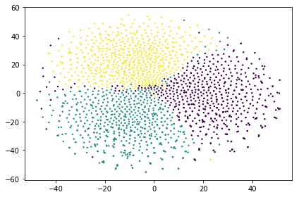

```python
#############################################
# SOLUCIÓ                                   #
#############################################

fig, ax = plt.subplots(1, 1)
ax.scatter(m2d[:,0].squeeze().tolist(), m2d[:,1].squeeze().tolist(), c=targets, s=2)
plt.tight_layout()
```

### 4 d. Troba els grups de textos usant diferents algorismes

**Implementació:** Usa *k-means* (amb *k=3*) per identificar els 3 grups d'articles i visualitza el resultat.

**Solució:**

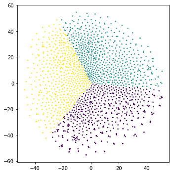

```python
#############################################
# SOLUCIÓ                                   #
#############################################

fig, ax = plt.subplots(1, 1, figsize=(5, 5))
kmeans = cluster.KMeans(n_clusters=3)
dists = kmeans.fit_transform(m2d)
ax.scatter(m2d[:,0], m2d[:,1], c=np.argmax(dists, axis=1), s=2)
plt.tight_layout()
```

**Anàlisi:** Has identificat els 3 grups originals? (el color no té perquè coincidir, només ens importa la forma) Per què?

**Solució:**  
No, perquè cada grup té una part més densa que no coincideix amb el centroide del grup, que seria el resultat desitjat.

Per tal d'agrupar els textos tractant de situar els centroides en les regions més denses, [Mean-Shift](http://scikit-learn.org/stable/modules/generated/sklearn.cluster.MeanShift.html) segueix un camí desde qualsevol punt de l'espai guiant-se per la densitat de punts fins a trobar un màxim local (dins de la seva *bandwidth*).

**Implementació:** Usa *Mean-Shift*, canviant la *bandwidth* fins a trobar 3 grups i visualitza el resultat.

**Solució:**

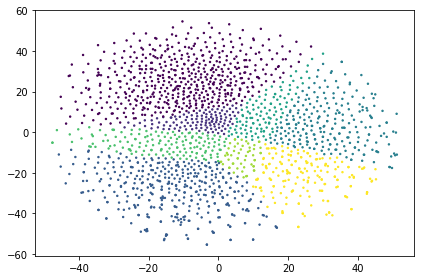

```python
#############################################
# SOLUCIÓ                                   #
#############################################

model = cluster.MeanShift(bandwidth=10, n_jobs=-1)
clusters = model.fit(m2d)

fig, ax = plt.subplots(1, 1)
ax.scatter(m2d[:,0], m2d[:,1], c=clusters.labels_, s=2)
plt.tight_layout()
```

**Anàlisi:** Has identificat els 3 grups originals? (el color no té perquè coincidir, només ens importa la forma) Per què?